# Taxonomy

```r
library("tidyr")
library(readr)
library(dplyr)
library(ggplot2)
library(viridis)
library(ggthemes)
```

# Import Data

## import taxonomy data

```r
raw_tax_clusters <- read_csv("merge_genome_by_genome_overview.csv")
```

| Assembly | X2 | Genome | Order | Family | Genus | VC | VC Status | Size | VC Subcluster | VC Subcluster Size | Quality | Adj P-value | Topology Confidence Score | Genera in VC | Families in VC | Orders in VC | Genus Confidence Score |
| --- | --- | --- | --- | --- | --- | --- | --- | --- | --- | --- | --- | --- | --- | --- | --- | --- | --- |
| B | 0 | Achromobacter~phage~83-24 | Caudovirales | Siphoviridae | Jwxvirus | 0_0 | Clustered | 2 | VC_0_0 | 2 | 0.1839 | 0.9522749 | 0.1752 | 1 | 1 | 1 | 1.0000 |
| B | 1 | Achromobacter~phage~JWAlpha | Caudovirales | Podoviridae | Jwalphavirus | 7_1 | Clustered | 13 | VC_7_1 | 13 | 0.4904 | 1.0000000 | 0.4904 | 4 | 1 | 1 | 0.8974 |
| B | 2 | Achromobacter~phage~JWX | Caudovirales | Siphoviridae | Jwxvirus | 0_0 | Clustered | 2 | VC_0_0 | 2 | 0.1839 | 0.9522749 | 0.1752 | 1 | 1 | 1 | 1.0000 |
| B | 3 | Achromobacter~phage~phiAxp-1 | Caudovirales | Siphoviridae | Unassigned | 1_0 | Clustered | 12 | VC_1_0 | 12 | 0.7161 | 1.0000000 | 0.7161 | 4 | 1 | 1 | 1.0000 |
| B | 4 | Achromobacter~phage~phiAxp-3 | Caudovirales | Podoviridae | Jwalphavirus | 7_1 | Clustered | 13 | VC_7_1 | 13 | 0.4904 | 1.0000000 | 0.4904 | 4 | 1 | 1 | 0.8974 |
| B | 5 | Acidianus~bottle-shaped~virus | Unassigned | Ampullaviridae | Ampullavirus | 17_0 | Clustered | 3 | VC_17_0 | 3 | 1.0000 | 1.0000000 | 1.0000 | 1 | 1 | 1 | 1.0000 |

make a column for unique subcluster based on assembly part of

```r
raw_tax_clusters$unique_vc_subcluster <- paste(raw_tax_clusters$Assembly,
                                               raw_tax_clusters$`VC Subcluster`,
                                               sep="--")
```

number of unique taxonomy clusters

```r
length(unique(raw_tax_clusters$unique_vc_subcluster))
```

sort the file based on VC subcluster

```r
tax_assigned_clusters <- separate(raw_tax_clusters, `VC Status`, into=c("VC_status", "overlaps"), sep=" ", remove = F)
```

```r
ANI_clusters <- read_tsv("merged_3000_trimmed_viruses_only_20211112_95-85_parsed.tsv", col_names=T)
```

```r
tax_assigned_clusters <- tax_assigned_clusters %>%
  full_join(ANI_clusters, by=c("Genome"="contig"))
```

```r
tail(tax_assigned_clusters)
```

```r
table(tax_assigned_clusters$VC_status[grepl("--", tax_assigned_clusters$Genome) & ])

table(tax_assigned_clusters$VC_status[grep("--", tax_assigned_clusters$Genome)])
length(unique(tax_assigned_clusters$unique_vc_subcluster[grep("--", tax_assigned_clusters$Genome)]))
table(tax_assigned_clusters$VC_status)
```

```r
vc_status <- reshape::melt(table(tax_assigned_clusters$VC_status[grep("--", tax_assigned_clusters$Genome)]))
colnames(vc_status) <- c("Status", "Count")
vc_status$binary <- "Not Clustered"
vc_status$binary[vc_status$Status=="Clustered"] <- "Clustered"
```

only keep clustered sequences

```r
tax_assigned_clusters <- tax_assigned_clusters[tax_assigned_clusters$VC_status=="Clustered",]
```

remove clusters that don’t have any of my contigs and that don’t have a taxonomy assignment

```r
tax_assigned_clusters$`Genera in VC`[is.na(tax_assigned_clusters$`Genera in VC`)] <- 0
tax_assigned_clusters$`Families in VC`[is.na(tax_assigned_clusters$`Families in VC`)] <- 0
tax_assigned_clusters$`Orders in VC`[is.na(tax_assigned_clusters$`Orders in VC`)] <- 0


tax_assigned_clusters <- tax_assigned_clusters[!(tax_assigned_clusters$`Genera in VC`==1 & tax_assigned_clusters$`Families in VC`==1 & tax_assigned_clusters$`Orders in VC`==1),]
```

```r
head(tax_assigned_clusters)
```

## Add consensus taxonomy

```r
clusters <- unique(tax_assigned_clusters$unique_vc_subcluster)
clusters <- clusters[!is.na(clusters)]
```

```r
tax_assigned_clusters$Consensus_Genus <- "Unassigned"
tax_assigned_clusters$Consensus_Family <- "Unassigned"
tax_assigned_clusters$Consensus_Order <- "Unassigned"
```

```r
for (cluster in clusters){
  tax_subset <- tax_assigned_clusters[!is.na(tax_assigned_clusters$`VC Subcluster`),]
  tax_subset <- tax_subset[tax_subset$unique_vc_subcluster == cluster,]
  genus <- unique(tax_subset$Genus[tax_subset$Genus != "Unassigned"])
  order <- unique(tax_subset$Order[tax_subset$Order != "Unassigned"])
  family <- unique(tax_subset$Family[tax_subset$Family != "Unassigned"])
  if (length(genus)==1){
    tax_assigned_clusters$Consensus_Genus[tax_assigned_clusters$unique_vc_subcluster == cluster] <- genus
    if (length(family) != 1) {family="Unassigned"}
    if (length(family) > 1) {family="mixed family"}
    tax_assigned_clusters$Consensus_Family[tax_assigned_clusters$unique_vc_subcluster == cluster] <- family
    if (length(order) != 1) {order="Unassigned"}
    if (length(order) > 1) {order="mixed order"}
    tax_assigned_clusters$Consensus_Order[tax_assigned_clusters$unique_vc_subcluster == cluster] <- order
  } else {
    if (length(genus) > 1) {
      tax_assigned_clusters$Consensus_Genus[tax_assigned_clusters$unique_vc_subcluster == cluster] <- "mixed genus"
    }
    if (length(family)==1){
      tax_assigned_clusters$Consensus_Family[tax_assigned_clusters$unique_vc_subcluster == cluster] <- family
      if (length(order) != 1) {order="Unassigned"}
      if (length(order) > 1) {order="mixed order"}
      tax_assigned_clusters$Consensus_Order[tax_assigned_clusters$unique_vc_subcluster == cluster] <- order
    } else {
      if (length(family) > 1) {
        tax_assigned_clusters$Consensus_Family[tax_assigned_clusters$unique_vc_subcluster == cluster] <- "mixed family"
      }
      if (length(order)==1){
        tax_assigned_clusters$Consensus_Order[tax_assigned_clusters$unique_vc_subcluster == cluster] <- order
      }
      else {
        if (length(order) > 1) {
          tax_assigned_clusters$Consensus_Order[tax_assigned_clusters$unique_vc_subcluster == cluster] <- "mixed order"
        }
      }
    }
  }
}
```

### only keep the viral populations

```r
tax_assigned_clusters_my_contigs <- tax_assigned_clusters[grep("--", tax_assigned_clusters$Genome),]
```

```r
write_tsv(tax_assigned_clusters, "tax_assigned_clusters", col_names = T)
write_tsv(tax_assigned_clusters_my_contigs, "tax_assigned_clusters_my_contigs.txt",col_names = T)
```

```r
length(unique(tax_assigned_clusters_my_contigs$unique_vc_subcluster))
```

```r
table(tax_assigned_clusters_my_contigs$Consensus_Genus)
table(tax_assigned_clusters_my_contigs$Consensus_Family)
table(tax_assigned_clusters_my_contigs$Consensus_Order)
```

```r
clusters <- read_tsv("merged_3000_trimmed_viruses_only_20211112_95-85_parsed.tsv", col_names=T)
clusters_unique <- clusters[!duplicated(clusters$cluster),]
```

```r
tax_assigned_clusters_viral_pops <- tax_assigned_clusters_my_contigs[tax_assigned_clusters_my_contigs$Genome %in% clusters_unique$contig,]
```

```r
table(tax_assigned_clusters_viral_pops$Consensus_Genus)
table(tax_assigned_clusters_viral_pops$Consensus_Family)
table(tax_assigned_clusters_viral_pops$Consensus_Order)
```

```r
levels(vc_status$Status)[1] <- "Clustered - Not Annotated"
levels(vc_status$Status)[2] <- "Clustered - Singleton"

levels(vc_status$Status) <- c(levels(vc_status$Status), "Clustered - Annotated")
vc_status <- rbind(vc_status, c("Clustered - Annotated", nrow(tax_assigned_clusters_my_contigs), "Clustered"))

vc_status$Count <- as.numeric(vc_status$Count)
vc_status$Count[vc_status$Status=="Clustered - Not Annotated"] <- vc_status$Count[vc_status$Status=="Clustered - Not Annotated"] - vc_status$Count[vc_status$Status=="Clustered - Annotated"]

vc_status$Status <- relevel(vc_status$Status, "Clustered - Annotated")

levels(vc_status$Status) <- c("Clustered - Annotated", "Clustered - Not Annotated",
                              "Clustered - Singleton", "Outlier", "Overlap", "Singleton")
```

```r
p2 <- ggplot(vc_status, aes(x=binary, y=Count,
                   color=Status, fill=Status)) +
  geom_col() +
  coord_flip() +
  theme(panel.background = element_blank(),
        axis.line = element_line(colour = "black"),
        panel.border = element_rect(colour = "black", fill=NA, size=1),
        axis.title=element_text(size=12),
        axis.text.y = element_text(size=12, colour = "black"),
        axis.text.x  = element_text(size=8, angle=0, vjust=1, hjust=0.5, colour="black"),
        plot.margin = unit(c(0.5, 1, 5, 0.6),"lines"),
        #legend.position = "bottom",
        legend.direction = "horizontal",
        legend.text = element_text(size=8),
        legend.position = c(0.2,-1.7)) +
  guides(fill=guide_legend(nrow=3, byrow=T), color=guide_legend(nrow=3, byrow=T)) +
  scale_colour_manual(name = '',
                     values = alpha(c("black", inferno(8)[7:2]), 1)) +
  scale_fill_manual(name = '',
                     values = alpha(c("black", inferno(8)[7:2]), 0.2)) +
  xlab("") +
  ylab("Number of Viral Populations")
p2
```

```r
png(filename="clusters.png", width=4, height=2, units = "in", res=300)
p2
dev.off()
```

### Flow diagram to visualize taxonomy

```r
library(networkD3)
library(reshape)
```

```r
links1 <- melt(table(tax_assigned_clusters_my_contigs$Consensus_Order,
                     tax_assigned_clusters_my_contigs$Consensus_Family))
colnames(links1) <- c("order", "family", "count")
links1 <- links1[links1$count!=0,]
links1 <- links1[order(links1$order),]
levels(links1$order)[2] <- "unassigned order"
levels(links1$family)[length(levels(links1$family))] <- "unassigned family"
links1
```

```r
links2 <-melt(table(tax_assigned_clusters_my_contigs$Consensus_Family,
                     tax_assigned_clusters_my_contigs$Consensus_Genus))
colnames(links2) <- c("family", "genus", "count")
links2 <- links2[links2$count!=0,]
levels(links2$family)[length(levels(links2$family))] <- "unassigned family"
levels(links2$genus)[levels(links2$genus)=="Unassigned"] <- "unassigned genus"
links2
```

```r
# A connection data frame is a list of flows with intensity for each flow
links <- data.frame()


links <- data.frame(
  source=c(as.character(links1$order), as.character(links2$family)),
  target=c(as.character(links1$family), as.character(links2$genus)),
  value=c(links1$count, links2$count)
)

# From these flows we need to create a node data frame: it lists every entities involved in the flow
nodes <- data.frame(
  name=c(as.character(links$source),
  as.character(links$target)) %>% unique()
)

# With networkD3, connection must be provided using id, not using real name like in the links dataframe.. So we need to reformat it.
links$IDsource <- match(links$source, nodes$name)-1
links$IDtarget <- match(links$target, nodes$name)-1

#nodes$group <- as.factor(c("a","a","a","b","b","a","b"))

#links$group <- as.factor(c("type_b","type_a","type_a","type_b","type_a","type_b"))

# prepare color scale: I give one specific color for each node.
#my_color <- 'd3.scaleOrdinal() .domain(["type_a", "type_b", "a", "b"]) .range(["#B63679FF", "#FB8861FF", "#B63679FF", "#FB8861FF"])'

p <- sankeyNetwork(Links = links, Nodes = nodes,
              Source = "IDsource", Target = "IDtarget",
              Value = "value", NodeID = "name",
              sinksRight=FALSE,
              fontSize = 18)

# Make the Network. I call my colour scale with the colourScale argument
#p <- sankeyNetwork(Links = links, Nodes = nodes, Source = "IDsource", Target = "IDtarget",
#              Value = "value", NodeID = "name",
#              colourScale=my_color, LinkGroup="group", NodeGroup="group",
#              fontSize = 26)
p

library(htmlwidgets)
saveWidget(p, file="sankey_taxonomy.html")
```

# For Cytoscape

## make a smaller version of the network file that only includes pairs with my contigs

```r
network_connections <- read_delim("c1_all_assemblies.ntw", delim = " ", col_names = F)
colnames(network_connections) <- c("Partner_One", "Partner_Two", "Weight")
network_connections$Partner_One <- sub(".*_3000_viralonly_", "", network_connections$Partner_One)
network_connections$Partner_Two <- sub(".*_3000_viralonly_", "", network_connections$Partner_Two)
```

```r
network_connections$In_One <- 0
network_connections$In_One[grep("--", network_connections$Partner_One)] <- 1

network_connections$In_Two <- 0
network_connections$In_Two[grep("--", network_connections$Partner_Two)] <- 1

network_connections$Keep <- network_connections$In_One + network_connections$In_Two
```

only keep genomes that are mine or connect with one of my contigs

```r
network_connections_subset <- network_connections[network_connections$Keep>0,]
```

remove any that are duplicates

```r
network_connections_subset$Both_Partners <- paste(network_connections_subset$Partner_One,
                                                  network_connections_subset$Partner_Two,
                                                  sep = "--")
network_connections_subset <- network_connections_subset[!duplicated(network_connections_subset$Both_Partners),]
```

### add color attribute

```r
network_connections_subset <- left_join(network_connections_subset, tax_assigned_clusters, by=c("Partner_One"="Genome"))
network_connections_subset <- network_connections_subset[,-c(4:6,12,14:24)]
colnames(network_connections_subset)[c((ncol(network_connections_subset)-2):ncol(network_connections_subset))] <-
  c("Consensus_Genus_Partner_One", "Consenus_Family_Partner_One", "Consensus_Order_Partner_One")
```

```r
head(network_connections_subset)
```

```r
network_connections_subset$consensus_source_color <- "black"
network_connections_subset$consensus_source_color[network_connections_subset$Consenus_Family_Partner_One=="Sphaerolipoviridae"] <- "light green"
network_connections_subset$consensus_source_color[network_connections_subset$Consenus_Family_Partner_One=="Inoviridae"] <- "light blue"
network_connections_subset$consensus_source_color[network_connections_subset$Consenus_Family_Partner_One=="Tectiviridae"] <- "brown"
network_connections_subset$consensus_source_color[network_connections_subset$Consenus_Family_Partner_One=="Microviridae"] <- "red"
network_connections_subset$consensus_source_color[network_connections_subset$Consenus_Family_Partner_One=="mixed family"] <- "black"
network_connections_subset$consensus_source_color[network_connections_subset$Consenus_Family_Partner_One=="Myoviridae"] <- "blue"
network_connections_subset$consensus_source_color[network_connections_subset$Consenus_Family_Partner_One=="Podoviridae"] <- "orange"
network_connections_subset$consensus_source_color[network_connections_subset$Consenus_Family_Partner_One=="Siphoviridae"] <- "green"
```

```r
network_connections_subset$source_color <- "black"
network_connections_subset$source_color[network_connections_subset$Family=="Sphaerolipoviridae"] <- "light green"
network_connections_subset$source_color[network_connections_subset$Family=="Inoviridae"] <- "light blue"
network_connections_subset$source_color[network_connections_subset$Family=="Tectiviridae"] <- "brown"
network_connections_subset$source_color[network_connections_subset$Family=="Microviridae"] <- "red"
network_connections_subset$source_color[network_connections_subset$Family=="Myoviridae"] <- "blue"
network_connections_subset$source_color[network_connections_subset$Family=="Podoviridae"] <- "orange"
network_connections_subset$source_color[network_connections_subset$Family=="Siphoviridae"] <- "green"
```

```r
write_tsv(network_connections_subset, file="c1_all_contigs.ntw", col_names = T)
```

```r
#network_connections_subset <- read_tsv("../PaperDrafts/CodeForPaper/c1_all_contigs.ntw", col_names = T)
```

```r
head(network_connections_subset)
```

## Reducing the number of contigs in the network graph

```r
merged_tpm <- read_tsv("abund_table_tpm_normalized_clusters_with_metadata.tsv")
```

```
Warning messages:
1: In readChar(file, size, TRUE) : truncating string with embedded nuls
2: In readChar(file, size, TRUE) : truncating string with embedded nuls
```

## create abundance table for diversity analyses

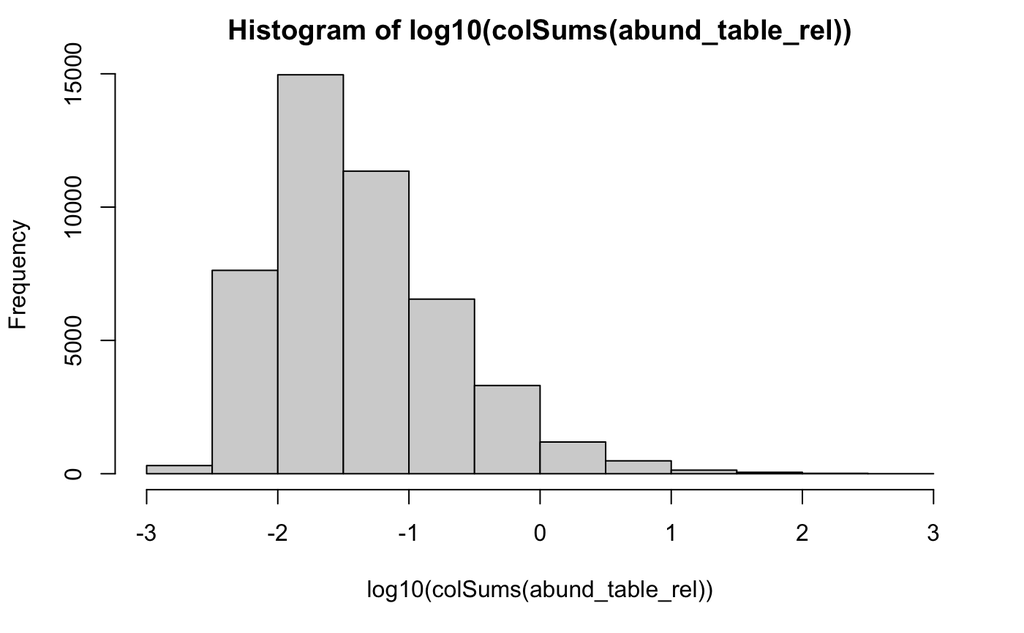

```r
abund_table <- merged_tpm[,-c((ncol(merged_tpm)-42):ncol(merged_tpm))]

abund_table_rel <-abund_table/rowSums(abund_table)*100
hist(log10(colSums(abund_table_rel)))
```

```r
table(colSums(abund_table_rel)>1)
```

```
FALSE  TRUE
44104  1879
```

```r
abund_table <- abund_table[,colSums(abund_table_rel)>1]
abund_table_rel <- abund_table_rel[,colnames(abund_table_rel) %in% colnames(abund_table)]

abund_table_pres <- apply(abund_table, c(1,2), function(x) if (x>0) {x=1} else {x=0})

abund_table_order <- abund_table_pres
abund_table_order[,] <- 0

for (i in 1:nrow(abund_table)) {
  ranking <- tibble(order=order(abund_table[i,], decreasing=T),
                    placement=seq(1:ncol(abund_table)))
  for (j in 1:ncol(abund_table)) {
    if (abund_table_pres[i,j]==1)
      abund_table_order[i,j] <- ranking$placement[ranking$order==j]
  }
}

abund_table_order_bin <- matrix(nrow=nrow(abund_table),
                            ncol=ncol(abund_table), data = 0)

for (i in 1:nrow(abund_table)) {
  num_clusters <- sum(abund_table_pres[i,])
  for (j in 1: ncol(abund_table)) {
    if (abund_table_order[i,j]<=(num_clusters*.1) & abund_table_order[i,j]!=0)
      abund_table_order_bin[i,j] <- 1
  }
}

table(abund_table_rel>10)
```

```
 FALSE   TRUE
307967    189
```

```r
abund_table_order_bin_1percent <- matrix(nrow=nrow(abund_table),
                            ncol=ncol(abund_table), data = 0)

for (i in 1:nrow(abund_table)) {
  for (j in 1: ncol(abund_table)) {
    if (abund_table_rel[i,j]>=1 & abund_table_order[i,j]!=0)
      abund_table_order_bin_1percent[i,j] <- 1
  }
}

abund_table_order_bin_10percent <- matrix(nrow=nrow(abund_table),
                            ncol=ncol(abund_table), data = 0)

for (i in 1:nrow(abund_table)) {
  for (j in 1: ncol(abund_table)) {
    if (abund_table_rel[i,j]>=10 & abund_table_order[i,j]!=0)
      abund_table_order_bin_10percent[i,j] <- 1
  }
}

num_samples_contig_in <- tibble(cluster=colnames(abund_table_pres),
                                samples_present_in=colSums(abund_table_pres),
                                read_abundance=colSums(abund_table),
                                rank=colSums(abund_table_order_bin),
                                rank1percent=colSums(abund_table_order_bin_1percent),
                                rank10percent=colSums(abund_table_order_bin_10percent))
```

```r
pal <- ggthemes::tableau_color_pal(palette="Tableau 10", type="regular")
num_samples_contig_in$color <- pal(2)[1]
num_samples_contig_in$color[num_samples_contig_in$samples_present_in>=16] <- pal(2)[2]
```

looking at the taxonomy of these abundant clusters

```r
tax_assigned_clusters_my_contigs <- read_tsv("tax_assigned_clusters_my_contigs.txt")
```

```
There were 22 warnings (use warnings() to see them)
```

```r
ANI_clusters <- read_tsv("merged_3000_trimmed_viruses_only_20211112_95-85_parsed.tsv", col_names=T)
```

```
Warning message:
In readChar(file, size, TRUE) : truncating string with embedded nuls
```

```r
num_samples_contig_in_subset <- num_samples_contig_in[num_samples_contig_in$rank1percent>1,] %>%
  left_join(ANI_clusters, by="cluster") %>%
  left_join(tax_assigned_clusters_my_contigs,
            by=c("contig"="Genome"))
```

```r
clusters <- unique(num_samples_contig_in_subset$cluster)
clusters <- clusters[!is.na(clusters)]
```

```r
num_samples_contig_in_subset$Consensus_Family_ANI <- "Unassigned"
```

```
There were 11 warnings (use warnings() to see them)
```

```r
for (cluster in clusters) {
  num_samples_contig_in_subset_cluster <- num_samples_contig_in_subset[num_samples_contig_in_subset$cluster == cluster,]
  family <- unique(num_samples_contig_in_subset_cluster$Consensus_Family[!is.na(num_samples_contig_in_subset_cluster$Consensus_Family)])
  order <- unique(num_samples_contig_in_subset_cluster$Consensus_Order[!is.na(num_samples_contig_in_subset_cluster$Consensus_Order)])
  if (length(family)==1) {
    num_samples_contig_in_subset$Consensus_Family_ANI[num_samples_contig_in_subset$cluster == cluster] <- family
  }
  else if (length(family) > 1) {
    num_samples_contig_in_subset$Consensus_Family_ANI[num_samples_contig_in_subset$cluster == cluster] <- "mixed family"
    if (length(order)==1) {
      num_samples_contig_in_subset$Consensus_Family_ANI[num_samples_contig_in_subset$cluster == cluster] <- "unknown family - Caudovirales"
    }
  }
}

num_samples_contig_in_subset <- num_samples_contig_in_subset[!duplicated(num_samples_contig_in_subset$cluster),]
```

### no color based on family

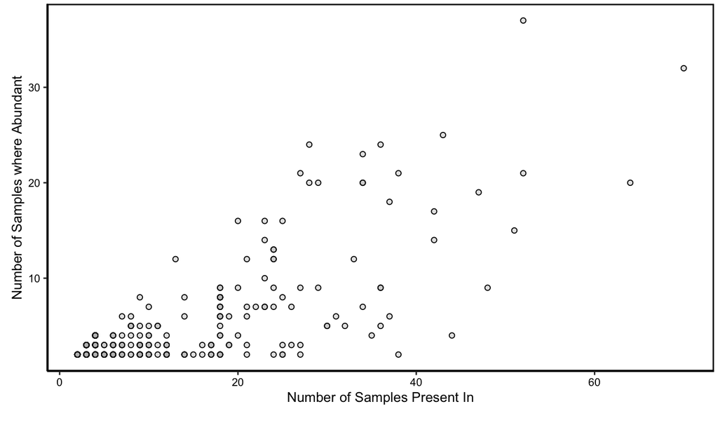

```r
p4 <- ggplot(num_samples_contig_in_subset, aes(x=samples_present_in,
                                            y=rank1percent,
                                            color=family_color,
                                            fill=family_color)) +
  geom_point(shape=21) +
  theme(panel.background = element_blank(),
        axis.line = element_line(colour = "black"),
        panel.border = element_rect(colour = "black", fill=NA, size=1),
        axis.text=element_text(size=8, colour="black"),
        axis.title=element_text(size=10),
        legend.key=element_blank(),
        legend.position = "none",
        plot.margin = unit(c(0.2, 0.2, 2, 0.6),"lines"),
        legend.direction = "horizontal",
        legend.text = element_text(size=8),
        legend.title = element_text(size=10),
        legend.background = element_blank()) +
  xlab("Number of Samples Present In") + ylab("Number of Samples where Abundant") +
  #scale_y_log10() +
  scale_fill_manual(name = '',
                   values = alpha(rep("grey", 6), 0.4),
                    labels = c("Unknown", "Myoviridae", "Siphoviridae",
                               "Unknown - Caudovirales", "Podoviridae", "Microviridae")
                    ) +
  scale_color_manual(name = '',
                    values = alpha(rep("black", 6), 1),
                    labels = c("Unknown", "Myoviridae", "Siphoviridae",
                               "Unknown - Caudovirales", "Podoviridae", "Microviridae")
                    )

p4
```

```r
png(filename="samples_abundant_vs_samples_present.png", width=5, height=4, units = "in", res=300)
p4
dev.off()
```

```r
num_samples_contig_in_top3 <- num_samples_contig_in[num_samples_contig_in$rank1percent>1,] %>%
  left_join(ANI_clusters, by="cluster") %>%
  left_join(tax_assigned_clusters_my_contigs,
            by=c("contig"="Genome"))
```

```r
num_samples_contig_in_top3[num_samples_contig_in_top3$samples_present_in>60 |
                               num_samples_contig_in_top3$rank1percent>30,]
```

top 3 (picked the ones that had the taxonomic assignment if multiple) 1) Cluster_905; SRR6797143–NODE_753_length_12267_cov_1_923052||full (taxonmic assignment); 12,243bp S41-73–NODE_704_length_55480_cov_706_982747||full; 55219bp 2) Cluster_2791; Dundee_Maria–Dundee_Maria_0001880||full (taxonomic assignment); 4462bp SRR6797136–NODE_313_length_35002_cov_69_726271||full; 35000bp 3) Cluster_1288; London_Maria–London_Maria_0000218||full; 46843bp

#looking at these a bit more

```r
VP_905 <- ANI_clusters[grep("Cluster_905", ANI_clusters$cluster),]
```

## import DRAM annotations

```r
annotations <- read_tsv("merged_annotations.tsv", col_names = T)
colnames(annotations)[2] <- "Geneid"
colnames(annotations)[4] <- "UniqContig"
colnames(annotations)[5] <- "Start"
colnames(annotations)[7] <- "End"
annotations <- annotations[,-1]
annotations <- separate(annotations, col="UniqContig", into=c("Assembly", "Contig"), sep = "--", remove = F)
```

```r
annotations_sub <- annotations[annotations$UniqContig=="SRR6797143--NODE_753_length_12267_cov_1_923052||full",]

write_tsv(annotations_sub, "annotations_SRR6797143--NODE_753_length_12267_cov_1_923052||full.tsv")
```

```r
annotations_sub <- annotations[annotations$UniqContig=="S41-73--NODE_704_length_55480_cov_706_982747||full",]

write_tsv(annotations_sub, "S41-73--NODE_704_length_55480_cov_706_982747||full.tsv")
```

```r
annotations_sub <- annotations[annotations$UniqContig=="Dundee_Maria--Dundee_Maria_0001880||full",]

write_tsv(annotations_sub, "Dundee_Maria--Dundee_Maria_0001880||full.tsv")
```

```r
annotations_sub <- annotations[annotations$UniqContig=="SRR6797136--NODE_313_length_35002_cov_69_726271||full",]

write_tsv(annotations_sub, "SRR6797136--NODE_313_length_35002_cov_69_726271||full.tsv")
```

```r
annotations_sub <- annotations[annotations$UniqContig=="London_Maria--London_Maria_0000218||full",]

write_tsv(annotations_sub, "London_Maria--London_Maria_0000218||full.tsv")
```

### consider a sample “high frequency” if it is in at least 10% of samples and use for making a map

```r
high_freq_contig <- num_samples_contig_in$contig[num_samples_contig_in$samples_present_in>(nrow(abund_table)/10)]
#high_freq_contig <- clusters[clusters$cluster %in% high_freq_contig,]
clusters_unique <- clusters[!duplicated(clusters$cluster),]
high_freq_contig <- clusters_unique[clusters_unique$cluster %in% high_freq_contig,]


network_connections_high_freq <- network_connections_subset

network_connections_high_freq$In_One <- 0
network_connections_high_freq$In_One[network_connections_high_freq$Partner_One %in% high_freq_contig$contig] <- 1

network_connections_high_freq$In_Two <- 0
network_connections_high_freq$In_Two[network_connections_high_freq$Partner_Two %in% high_freq_contig$contig] <- 1

network_connections_high_freq$In_One[!grepl("--", network_connections_high_freq$Partner_One)] <- 0.5

network_connections_high_freq$In_Two[!grepl("--", network_connections_high_freq$Partner_Two)] <- 0.5

network_connections_high_freq$Keep <- network_connections_high_freq$In_One + network_connections_high_freq$In_Two

network_connections_high_freq <- network_connections_high_freq[network_connections_high_freq$Keep>1,]
```

```r
write_tsv(network_connections_high_freq, file="c1_high_freq_viral_pops_and_connected_genomes.ntw", col_names = T)
```